# RNA Folding Notebook

This notebook generates RNA secondary structure predictions using ViennaRNA and visualizes them with forgi.

- load precomputed SHAPE reactivity data,
- sample sequences per experiment,
- compute unconstrained and SHAPE-constrained folds,
- and render comparison plots (SHAPE-colored bases).

The goal is to provide a compact, reproducible workflow for examining RNA folding behavior and assessing how reactivity values influence folding predictions.

## Environment & Imports

This section sets up all required packages for RNA folding, data handling, and visualization.

```python
# =======================
# Imports & Environment Setup
# =======================

# === Standard library ===
from pathlib import Path        # convenient filesystem path handling
import os                      # OS-level utilities (optional but useful)
import re                      # regex utilities (string parsing, pattern matching)
import warnings                # to silence library warnings when needed
import glob

# === Core data & storage packages ===
import pandas as pd            # DataFrames and CSV/Parquet IO
import numpy as np             # numerical computing & arrays
import pyarrow as pa           # Arrow in-memory table representation
import pyarrow.parquet as pq   # Parquet read/write support

# === RNA structure & folding === #for those packages don't forget to run the install on kaggle's console (add-ons --> install dependencies -> run)
import RNA                     # ViennaRNA: RNA folding & energy calculations
import forgi                   # Forgi: secondary structure graph toolkit
import forgi.graph.bulge_graph as fgb       # bulge graph parser
import forgi.visual.mplotlib as fvm        # visualizations for RNA structures

# === Plotting / visualization ===
import matplotlib              # low-level plotting engine
import matplotlib.pyplot as plt            # main plotting interface
import matplotlib.colors as mcolors        # color utilities (e.g., colormaps)
from matplotlib.text import Annotation
from PIL import Image
#plot preferences
plt.rcParams.update({
    "figure.facecolor": "#17191a",
    "axes.facecolor":   "#17191a",
    "axes.edgecolor":   "white",
    "text.color":       "white",
    "axes.labelcolor":  "white",
    "xtick.color":      "white",
    "ytick.color":      "white",
})

# =======================
# Version Checks
# =======================
print("numpy:", np.__version__)       # check numpy version
print("forgi:", forgi.__version__)    # check Forgi installation
print("RNA (ViennaRNA):", RNA.__version__)  # RNA folding engine version
print("pyarrow:", pa.__version__)     # check Arrow version

# =======================
# Runtime Paths & Output Config
# =======================
OUT_ROOT = Path("/kaggle/working")            # working directory for outputs
SAVE_PATH = OUT_ROOT / "fold_inputs.parquet"  # location to store processed data

# =======================
# Load Dataset
# =======================
train = pd.read_csv(
    "/kaggle/input/stanford-ribonanza-rna-folding/train_data_QUICK_START.csv"
)  # read training data subset

# Basic dataset inspection
print("Rows:", len(train))                     # number of samples
print("Example columns:", list(train.columns)[:12])  # first 12 columns for preview
```

```
numpy: 1.26.4
forgi: 2.2.3
RNA (ViennaRNA): 2.7.0
pyarrow: 19.0.1
Rows: 335616
Example columns: ['sequence_id', 'sequence', 'experiment_type', 'dataset_name', 'reactivity_0001', 'reactivity_0002', 'reactivity_0003', 'reactivity_0004', 'reactivity_0005', 'reactivity_0006', 'reactivity_0007', 'reactivity_0008']
```

## SHAPE Reactivity Preprocessing

This section prepares the dataset for folding by:

- detecting key columns (sequence, experiment labels, sequence IDs),
- identifying all `reactivity_*` columns,
- converting each row into a SHAPE vector aligned to its sequence,
- grouping data by experiment type,
- and writing the processed results to a compressed Parquet file.

The batching and vector conversion keep memory usage efficient when handling large RNA datasets.

```python
# ================== CONFIG ==================
BATCH_ROWS = 2000                # tune for RAM / speed
FILL = np.float32(-999.0)        # ViennaRNA-style missing marker

# ================== COLUMN DETECTION ==================
# Required: sequence column
if "sequence" in train.columns:
    seq_col = "sequence"
else:
    raise ValueError("No 'sequence' column found in train.")

# Optional: experiment column
exp_col = None
for c in ("experiment_type", "exp", "experiment"):
    if c in train.columns:
        exp_col = c
        break

if exp_col is not None and not isinstance(train[exp_col].dtype, pd.CategoricalDtype):
    train[exp_col] = train[exp_col].astype("category")

# Optional: sequence_id column
seq_id_col = None
for c in ("sequence_id", "id", "seq_id"):
    if c in train.columns:
        seq_id_col = c
        break

# ================== REACTIVITY COLUMNS ==================
pat = re.compile(r"reactivity_(\d+)$")
keyed = []
for c in train.columns:
    m = pat.match(str(c))
    if m:
        keyed.append((int(m.group(1)), c))

react_cols = [c for _, c in sorted(keyed)]
if not react_cols:
    raise ValueError("No reactivity_* columns found in train.")

# ================== EXPERIMENT GROUPING ==================
def map_exp(x):
    if x == "DMS_MaP":
        return "DMS"
    if x == "2A3_MaP":
        return "2A3"
    return "ALL"

if exp_col is None:
    groups = [("ALL", train)]
else:
    groups = []
    cats = train[exp_col].cat.categories if hasattr(train[exp_col], "cat") else train[exp_col].unique()
    for lbl in cats:
        sub = train.loc[train[exp_col].astype(str).eq(str(lbl))]
        if len(sub):
            groups.append((map_exp(lbl), sub))

# ================== SEQUENCE → SHAPE VECTOR ==================
def row_to_shape(seq: str, row_vals: np.ndarray) -> np.ndarray:
    """
    seq: RNA sequence (string)
    row_vals: reactivity values for this row (1-based positions in columns)
    Returns: float16 vector of length len(seq), filled with FILL where missing.
    """
    L = len(seq) if isinstance(seq, str) else 0
    if L <= 0:
        return np.full(0, FILL, dtype=np.float16)

    v = np.full(L, FILL, dtype=np.float16)

    vals = row_vals.astype(np.float32, copy=False)
    vals = vals[:L]  # truncate if we have more columns than sequence length

    mask = np.isfinite(vals)
    if mask.any():
        v[np.nonzero(mask)[0]] = vals[mask].astype(np.float16, copy=False)
    return v

# ================== CLEAN START: REMOVE OLD FILE ==================
if SAVE_PATH.exists():
    SAVE_PATH.unlink()

SAVE_PATH.parent.mkdir(parents=True, exist_ok=True)

# ================== PARQUET WRITER LOOP ==================
writer = None
total_rows = 0

cols_needed = []
if seq_id_col:
    cols_needed.append(seq_id_col)
cols_needed.append(seq_col)
cols_needed.extend(react_cols)
cols_needed = [c for c in cols_needed if c is not None]

for exp_short, df_exp in groups:
    if df_exp.empty:
        continue

    df_exp = df_exp[cols_needed].copy()
    exp_rows = 0

    for start in range(0, len(df_exp), BATCH_ROWS):
        end = min(start + BATCH_ROWS, len(df_exp))
        batch = df_exp.iloc[start:end]

        # reactivity matrix
        R = batch[react_cols].to_numpy(dtype=np.float32, copy=False)

        out_rows = []
        seq_vals = batch[seq_col].astype("string").to_numpy()
        ids = batch[seq_id_col].to_numpy() if seq_id_col else None

        for i, seq in enumerate(seq_vals):
            seq_str = "" if seq is pd.NA else str(seq)
            vec = row_to_shape(seq_str, R[i])

            row = {
                "experiment": exp_short,
                "sequence": seq_str,
                "shape_vec": vec,
            }
            if ids is not None:
                row["sequence_id"] = ids[i]
            out_rows.append(row)

        df_out = pd.DataFrame(out_rows)

        # nice column order
        col_order = []
        if "sequence_id" in df_out.columns:
            col_order.append("sequence_id")
        col_order += ["sequence", "experiment", "shape_vec"]
        df_out = df_out[col_order]

        # convert ndarray → list for parquet
        df2 = df_out.copy()
        df2["shape_vec"] = df2["shape_vec"].apply(lambda a: a.tolist())

        table = pa.Table.from_pandas(df2, preserve_index=False)

        # lazily create writer when we see first chunk
        if writer is None:
            writer = pq.ParquetWriter(
                SAVE_PATH,
                table.schema,
                compression="zstd"
            )

        writer.write_table(table)
        batch_n = len(df_out)
        total_rows += batch_n
        exp_rows += batch_n

    # one summary line per experiment
    print(f"Experiment {exp_short}: wrote {exp_rows} rows")

if writer is not None:
    writer.close()

print(f"\nSaved fold_inputs to: {SAVE_PATH} with {total_rows} total rows")
```

```
Experiment 2A3: wrote 167808 rows
Experiment DMS: wrote 167808 rows

Saved fold_inputs to: /kaggle/working/fold_inputs.parquet with 335616 total rows
```

## Load Processed Fold Inputs

This step reads the precomputed Parquet file, restores each `shape_vec` back into a numeric array, and re-applies the categorical ordering for the experiment labels.  
The resulting `fold_inputs` DataFrame is the standardized input used for all folding and visualization steps that follow.

```python
fi = pd.read_parquet(SAVE_PATH, engine="pyarrow")

# Restore arrays and (optionally) the categorical order
fi["shape_vec"] = fi["shape_vec"].apply(lambda x: np.asarray(x, dtype=np.float32))
fi["experiment"] = pd.Categorical(fi["experiment"], categories=["2A3","DMS"], ordered=True)

fold_inputs = fi  # use as before
print(fold_inputs.shape, fold_inputs.columns.tolist())
fi.head(1)
```

```
(335616, 4) ['sequence_id', 'sequence', 'experiment', 'shape_vec']
```

|  | sequence_id | sequence | experiment | shape_vec |
| --- | --- | --- | --- | --- |
| 0 | 0000d87cab97 | GGGAACGACUCGAGUAGAGUCGAAAAAGAUCGCCACGCACUUACGA... | 2A3 | [-999.0, -999.0, -999.0, -999.0, -999.0, -999.... |

## SHAPE Handling & Folding Utilities

This section defines two core helpers:

- **`to_float_list`**  
  Cleans and normalizes SHAPE vectors by converting values to floats and replacing invalid entries with `-999.0`, the placeholder used by ViennaRNA for missing constraints.
- **`fold_with_vienna`**  
  Applies the Deigan SHAPE model to compute an MFE secondary structure using ViennaRNA, with automatic sequence normalization and constraint validation.

The `shape_vec` column is also forced to stay as Python lists to ensure compatibility with the folding functions.

```python
def to_float_list(vec):
    """
    Convert a SHAPE reactivity vector (list/array) into a clean Python list[float].

    Rules:
      • Cast numeric values to float
      • Replace invalid / None / NaN / non-numeric values with -999.0
        (ViennaRNA uses -999 to indicate "missing constraint")
      • Always return a flat Python list, never NumPy array
    """
    # Ensure 1-D vector input: flatten numpy array or convert to 1-D array of objects
    if isinstance(vec, np.ndarray):
        v = vec.ravel()
    else:  # handle Python lists / pandas cells that may contain objects
        v = np.array(vec, dtype=object).ravel()

    out = []
    for x in v:
        # Missing values → placeholder
        if x is None:
            out.append(-999.0)
            continue

        # Try converting to float safely
        try:
            xf = float(x)
            # NaN / ±inf → missing
            out.append(xf if np.isfinite(xf) else -999.0)
        except Exception:
            # Non-numeric string / corrupted entry → missing
            out.append(-999.0)

    return out


def fold_with_vienna(seq, vec, m=1.9, b=-0.7):
    """
    Fold an RNA sequence using ViennaRNA with SHAPE constraints (Deigan model).

    Args:
        seq : RNA/DNA string (DNA 'T' automatically converted to RNA 'U')
        vec : SHAPE vector (raw input → cleaned with to_float_list)
        m, b: Deigan SHAPE parameters
              m = slope, b = intercept (default recommended values)

    Steps:
      • Convert sequence to RNA alphabet
      • Clean SHAPE values (replace invalid with -999)
      • Validate length match between sequence and SHAPE vector
      • Apply SHAPE constraints to ViennaRNA fold_compound
      • Compute MFE structure & energy

    Returns:
        ss  : predicted secondary structure (dot-bracket)
        mfe : minimum free energy (float)
    """
    # Convert DNA sequences to RNA form
    seq = str(seq).replace("T", "U")

    # Normalize SHAPE vector to float list with -999 for missing
    v = to_float_list(vec)

    # Sequence + SHAPE vector must match length
    if len(v) != len(seq):
        raise ValueError(f"shape_vec length {len(v)} != sequence length {len(seq)}")

    # Create ViennaRNA folding object
    fc = RNA.fold_compound(seq)

    # Add SHAPE reactivity constraints (Deigan method)
    # -999 entries are interpreted as "no constraint"
    fc.sc_add_SHAPE_deigan(v, float(m), float(b), 0)

    # Compute minimum free energy structure
    ss, mfe = fc.mfe()
    return ss, float(mfe)


# Ensure the SHAPE vector column stays Python objects (lists),
# not automatically converted to arrays/strings by pandas
fold_inputs["shape_vec"] = fold_inputs["shape_vec"].astype(object)
```

## Sampling and SHAPE-Guided Folding

Takes a small balanced subset of sequences by sampling `k` examples per experiment, then compute:

- the SHAPE-constrained minimum free energy (MFE) structure, and
- the corresponding dot-bracket notation,

It uses the `fold_with_vienna` helper.  
This subset is used for visualization and comparison across experimental conditions.

```python
# === sample k per Experiment ===
k = 5

sample_bal = (
    fold_inputs
    .sample(frac=1, random_state=42)        # shuffle entire dataset
    .groupby("experiment", group_keys=False, observed=True)
    .head(k)                                # take first k rows per group
    .reset_index(drop=True)
    .copy()
)



# === compute dot-bracket + MFE for each sequence ===
sample_bal[["dotbracket","mfe_kcal_mol"]] = sample_bal.apply(
    lambda r: pd.Series(fold_with_vienna(r["sequence"], r["shape_vec"])),
    axis=1
)
sample_bal.head(5)
```

|  | sequence_id | sequence | experiment | shape_vec | dotbracket | mfe_kcal_mol |
| --- | --- | --- | --- | --- | --- | --- |
| 0 | 668f569eee56 | GGGAACGACUCGAGUAGAGUCGAAAAGAUAUGGACGCUACACUUCG... | 2A3 | [-999.0, -999.0, -999.0, -999.0, -999.0, -999.... | .....((((((.....))))))....(((..((((((..(((((((... | -103.309998 |
| 1 | 875614d6421e | GGGAACGACUCGAGUAGAGUCGAAAAGAUAUGGAGCCACCACUUUC... | 2A3 | [-999.0, -999.0, -999.0, -999.0, -999.0, -999.... | .....((((((.....))))))....(((..((((((((...((((... | -109.669998 |
| 2 | dd2b3f30d889 | GGGAACGACUCGAGUAGAGUCGAAAAAACCAGGGCUUUAACUGCAG... | 2A3 | [-999.0, -999.0, -999.0, -999.0, -999.0, -999.... | (....((((((.....)))))).......(((........)))(((... | -64.620003 |
| 3 | f7ab4d05960d | GGGAACGACUCGAGUAGAGUCGAAAAACAAGCUCCAGUCUCAGAUU... | 2A3 | [-999.0, -999.0, -999.0, -999.0, -999.0, -999.... | ((((.((((((.....)))))).......(((.(((((..(........ | -59.119999 |
| 4 | 2b3b066539d2 | GGGAACGACUCGAGUAGAGUCGAAAACACUCAUUUGUCUGGUCUAG... | DMS | [-999.0, -999.0, -999.0, -999.0, -999.0, -999.... | .....((((((.....))))))......((((((((((((((((((... | -82.470001 |

### What MFE Means in RNA Folding

**MFE (Minimum Free Energy)** refers to the predicted RNA secondary structure with the **lowest free energy (ΔG)**.  
It represents the most thermodynamically stable structure:

- **More negative ΔG → more stable / likely structure**
- **Less negative ΔG → less stable / more flexible or unfolded**

ViennaRNA computes the MFE structure using dynamic programming and its thermodynamic energy model.

### When Using SHAPE-Guided Folding

With SHAPE (Selective 2′-Hydroxyl Acylation analyzed by Primer Extension) data:

- SHAPE reactivities adjust pairing penalties to better reflect real structure
- The reported **MFE** is still in kcal/mol, but now informed by both **sequence** and **experimental reactivity**
- This produces an **MFE structure that is more biologically realistic**

(You may also see ensemble energy or diversity metrics, but MFE is the primary value.)

### In short

**MFE = free energy of the most stable predicted RNA structure.**  
With SHAPE data, the structure and its energy incorporate experimental constraints.

## RNA Quality Control Metrics

This section computes per-sequence QC metrics to assess the reliability and behavior of SHAPE-guided folding.  
It includes:

- helpers for parsing dot-bracket pairing,
- SHAPE vector cleaning and padding,
- constrained folding with ViennaRNA,
- and a `qc_fold_row` function that reports:
  - sequence length and SHAPE coverage,
  - capped reactivity fraction,
  - paired vs unpaired median reactivity shift,
  - DMS-specific A/C vs G/U reactivity check,
  - distance to the unconstrained MFE structure,
  - ensemble diversity from the partition function.

The QC metrics are applied row-wise to the sampled subset and merged with basic identifiers for inspection.

```python
# ================================
# RNA QC helpers + per-row checks
# ================================

import numpy as np
import pandas as pd
import RNA  # ViennaRNA

# === helpers ===
def _pairs_mask(ss: str, L: int) -> np.ndarray:
    """
    Return a boolean mask of length L where True marks nucleotides
    that are base-paired in a dot-bracket string `ss`.

    Notes:
      • Uses a simple stack to match '(' with ')'
      • 1-based dot-bracket indexing → convert to 0-based for mask
      • Unbalanced trailing ')' are ignored safely
    """
    m = np.zeros(L, dtype=bool)
    st = []
    for i, ch in enumerate(ss, start=1):
        if ch == '(':
            st.append(i)
        elif ch == ')':
            if not st:
                break          # unmatched ')': stop rather than crash
            i0 = st.pop()      # matching '(' position (1-based)
            m[i0 - 1] = True
            m[i - 1]  = True
    return m


def _float_list(vec, L: int) -> list[float]:
    """
    Normalize an input vector (list/array/Series) to a flat Python list
    of length L with numeric floats. Invalid or missing values are set to -999.0
    (ViennaRNA sentinel for 'no constraint').

    Behavior:
      • Truncates extra elements beyond L
      • Pads with -999.0 if shorter than L
      • Treats NaN/±inf/non-numeric as missing
    """
    v = np.array(vec, dtype=object).ravel()
    out: list[float] = []
    for x in v[:L]:
        try:
            xf = float(x)
            out.append(xf if np.isfinite(xf) else -999.0)
        except Exception:
            out.append(-999.0)
    if len(out) < L:
        out += [-999.0] * (L - len(out))
    return out


def fold_with_vienna(seq: str, vec, m: float = 1.9, b: float = -0.7) -> tuple[str, float]:
    """
    Fold an RNA sequence with ViennaRNA using SHAPE (Deigan) constraints.

    Args:
        seq: RNA/DNA sequence (any 'T' is converted to 'U')
        vec: SHAPE reactivity vector (any sequence-like); cleaned via _float_list
        m, b: Deigan parameters (slope m, intercept b)

    Returns:
        (dotbracket_structure, mfe_kcal_mol)
    """
    # Ensure RNA alphabet
    seq = str(seq).replace("T", "U")
    # Clean / pad SHAPE to sequence length
    v = _float_list(vec, len(seq))

    # Build fold compound + add SHAPE constraints; -999 are treated as missing
    fc = RNA.fold_compound(seq)
    fc.sc_add_SHAPE_deigan(v, float(m), float(b), 0)

    # Minimum Free Energy structure
    ss, mfe = fc.mfe()
    return ss, float(mfe)


def qc_fold_row(row: pd.Series, m: float = 1.9, b: float = -0.7) -> pd.Series:
    """
    Compute QC metrics for a single row containing:
      • sequence        : str
      • shape_vec       : sequence-like of SHAPE values
      • dotbracket?     : optional precomputed dot-bracket (uses it if present)
      • experiment      : optional label ("DMS" used for AC>GU check)

    Returns a Series with:
      L, coverage, frac_capped,
      delta_unpaired_minus_paired, med_AC, med_GU, dms_like_AC>GU,
      bp_distance_vs_unconstrained, ensemble_diversity
    """
    # Canonicalize inputs
    seq = str(row["sequence"]).replace("T", "U")
    L = len(seq)

    # Clean SHAPE and compute coverage stats
    v = np.array(_float_list(row["shape_vec"], L), dtype=float)
    cov = np.isfinite(v) & (v != -999.0)
    coverage = float(cov.mean())                 # fraction of positions with usable SHAPE
    frac_capped = float((v >= 10 - 1e-9).sum()) / L  # crude cap fraction at >= 10

    # Use provided constrained structure if available; otherwise fold with SHAPE
    if "dotbracket" in row and isinstance(row["dotbracket"], str):
        ss = row["dotbracket"]
    else:
        ss = fold_with_vienna(seq, v, m=m, b=b)[0]

    # === Pairing signal: median unpaired vs paired reactivity ===
    pm = _pairs_mask(ss, L)  # True where paired
    w = v.copy()
    w[~cov] = np.nan         # ignore missing when taking medians

    med_unp = float(np.nanmedian(w[~pm])) if np.any((~pm) & cov) else np.nan
    med_p   = float(np.nanmedian(w[ pm])) if np.any(( pm) & cov) else np.nan
    delta   = (med_unp - med_p) if np.isfinite(med_unp) and np.isfinite(med_p) else np.nan

    # === DMS sanity: A/C should be more reactive than G/U under DMS ===
    bases = np.frombuffer(seq.encode(), dtype="S1").astype(str)
    ac = np.isin(bases, ["A", "C"])
    med_ac = float(np.nanmedian(w[ac]))   if np.any(ac & cov)    else np.nan
    med_gu = float(np.nanmedian(w[~ac]))  if np.any((~ac) & cov) else np.nan
    dms_like = (med_ac > med_gu) if row.get("experiment") == "DMS" else np.nan

    # === Compare constrained to unconstrained MFE; ensemble diversity ===
    ss0, _ = RNA.fold_compound(seq).mfe()                 # unconstrained MFE
    bp_dist = RNA.bp_distance(ss0, ss)                    # base-pair distance between ss0 and ss

    # Partition function with constraints to get ensemble characteristics
    fc = RNA.fold_compound(seq)
    fc.sc_add_SHAPE_deigan(v.tolist(), float(m), float(b), 0)
    fc.pf()
    ensemble_div = fc.mean_bp_distance()

    return pd.Series({
        "L": L,
        "coverage": coverage,
        "frac_capped": frac_capped,
        "delta_unpaired_minus_paired": delta,
        "med_AC": med_ac,
        "med_GU": med_gu,
        "dms_like_AC>GU": dms_like,
        "bp_distance_vs_unconstrained": bp_dist,
        "ensemble_diversity": ensemble_div,
    })


# ================================
# Run QC on your selected subset
# ================================

# Make a working copy (avoid mutating the original selection)
sample_subset = sample_bal.copy()

# Ensure we have structures: fold if column is missing
if "dotbracket" not in sample_subset.columns:
    sample_subset[["dotbracket", "mfe_kcal_mol"]] = sample_subset.apply(
        lambda r: pd.Series(fold_with_vienna(r["sequence"], r["shape_vec"])),
        axis=1
    )

# Compute QC metrics row-wise
qc_sampled = sample_subset.apply(qc_fold_row, axis=1)

# Concatenate identifiers with QC metrics for a compact view
display(pd.concat(
    [
        sample_subset[["sequence_id", "experiment"]].reset_index(drop=True),
        qc_sampled.reset_index(drop=True),
    ],
    axis=1
))
```

[output not shown]

### What this QC table shows (RNA QC helpers + per-row checks)

**Goal:** sanity-check SHAPE data and the resulting SHAPE-guided folds.

**How the code works (high level):**

- Converts `T→U`, cleans `shape_vec` to floats of length *L* (`-999.0` = “no constraint”).
- If `dotbracket` is missing, folds with ViennaRNA using **Deigan** parameters *(m=1.9, b=-0.7)*.
- Computes medians over **paired vs unpaired** nucleotides (from the dot-bracket) and simple QC stats.

**Column glossary:**

- `L` — sequence length.
- `coverage` — fraction of positions with usable SHAPE (finite and ≠ `-999.0`).
- `frac_capped` — fraction of positions with very high reactivity (≥ 10); rough cap/ceiling check.
- `delta_unpaired_minus_paired` — median(SHAPE at unpaired) − median(SHAPE at paired).  
  Larger positive values = SHAPE agrees with pairing.
- `med_AC`, `med_GU` — median reactivity on A/C vs G/U bases.
- `dms_like_AC>GU` — for rows where `experiment == "DMS"`, `True` if median(A/C) > median(G/U); else `NaN`.
- `bp_distance_vs_unconstrained` — base-pair distance between **unconstrained** MFE (sequence-only) and the **constrained** structure used above.
- `ensemble_diversity` — mean base-pair distance within the **constrained** ensemble (after adding SHAPE).

*Notes:*

## SHAPE-Aware Folding Comparison Features

This section defines utilities for comparing unconstrained and SHAPE-constrained RNA folds.  
It provides:

- normalization of SHAPE vectors,
- unconstrained (NC) and SHAPE-constrained (SC) folding functions,
- base-pairing masks from dot-bracket strings,
- and `add_compare_features`, which computes:
  - constrained vs unconstrained MFE,
  - base-pair distance,
  - ensemble diversity (NC and SC),
  - ΔED and ΔMFE,
  - and the separation between unpaired/paired SHAPE signals.

The resulting features summarize how SHAPE data influences the predicted structure for each sequence.

```python
# ================================
# SHAPE-aware folding & comparison helpers (ViennaRNA)
# ================================

import numpy as np
import pandas as pd
import RNA  # ViennaRNA

def _float_list(vec, L):
    """
    Normalize a SHAPE vector to a Python list[float] of length L.

    Rules:
      - Cast to float where possible.
      - Replace invalid / None / NaN / ±inf with -999.0 (ViennaRNA sentinel = "no constraint").
      - Truncate to L if longer; pad with -999.0 if shorter.
    """
    v = np.array(vec, dtype=object).ravel()
    out = []
    for x in v[:L]:
        try:
            xf = float(x)
            out.append(xf if np.isfinite(xf) else -999.0)
        except Exception:
            out.append(-999.0)
    if len(out) < L:
        out += [-999.0] * (L - len(out))
    return out


def fold_nc(seq):
    """
    Unconstrained MFE folding (sequence only).
    Returns: (dot_bracket, mfe_kcal_mol)
    """
    seq = str(seq).replace("T", "U")
    fc = RNA.fold_compound(seq)
    ss, mfe = fc.mfe()
    return ss, float(mfe)


def fold_sc(seq, vec, m=1.9, b=-0.7):
    """
    SHAPE-constrained MFE folding using Deigan pseudo-energies.
    Args:
        seq : RNA/DNA (T→U converted)
        vec : SHAPE reactivity vector (any sequence-like)
        m,b : Deigan parameters (slope, intercept)
    Returns:
        (dot_bracket, mfe_kcal_mol, cleaned_shape_list)
    """
    seq = str(seq).replace("T", "U")
    v = _float_list(vec, len(seq))
    fc = RNA.fold_compound(seq)
    # -999 values are interpreted as "no constraint"
    fc.sc_add_SHAPE_deigan(v, float(m), float(b), 0)
    ss, mfe = fc.mfe()
    return ss, float(mfe), v


def paired_mask(ss):
    """
    Build a boolean mask (len = len(ss)) where True marks paired positions
    in a dot-bracket string. Uses a stack to match '(' with ')'.
    """
    m = np.zeros(len(ss), dtype=bool)
    st = []
    for i, ch in enumerate(ss):
        if ch == '(':
            st.append(i)
        elif ch == ')' and st:
            j = i
            i0 = st.pop()
            m[i0] = True
            m[j]  = True
    return m


def add_compare_features(df: pd.DataFrame) -> pd.DataFrame:
    """
    For each row with columns:
        sequence, shape_vec, (optional) dotbracket, (optional) mfe_kcal_mol
    compute and add:
        - dotbracket_nc, mfe_nc                (unconstrained fold)
        - bp_distance                          (unconstrained vs constrained structure)
        - ED_nc, ED_sc, dED                    (ensemble diversity)
        - dMFE                                 (mfe_sc - mfe_nc; note sc includes pseudo-energies)
        - signal_sep                           (median_unpaired - median_paired, on constrained ss)

    Returns a copy of df with added columns; does not mutate input.
    """
    out = df.copy()

    # Ensure constrained folding results exist (compute if missing)
    if not {"dotbracket", "mfe_kcal_mol"}.issubset(out.columns):
        out[["dotbracket", "mfe_kcal_mol"]] = out.apply(
            lambda r: pd.Series(fold_sc(r["sequence"], r["shape_vec"])[:2]),
            axis=1
        )

    # Unconstrained folding (sequence-only baseline)
    out[["dotbracket_nc", "mfe_nc"]] = out.apply(
        lambda r: pd.Series(fold_nc(r["sequence"])),
        axis=1
    )

    # Base-pair distance between unconstrained and constrained structures
    out["bp_distance"] = out.apply(
        lambda r: RNA.bp_distance(r["dotbracket_nc"], r["dotbracket"]),
        axis=1
    )

    # Ensemble diversity helpers (mean base-pair distance over ensemble)
    def _ed_nc(seq: str) -> float:
        fc = RNA.fold_compound(seq.replace("T", "U"))
        fc.pf()
        return fc.mean_bp_distance()

    def _ed_sc(seq: str, vec) -> float:
        s = seq.replace("T", "U")
        v = _float_list(vec, len(s))
        fc = RNA.fold_compound(s)
        fc.sc_add_SHAPE_deigan(v, 1.9, -0.7, 0)
        fc.pf()
        return fc.mean_bp_distance()

    out["ED_nc"] = out["sequence"].apply(_ed_nc)
    out["ED_sc"] = out.apply(lambda r: _ed_sc(r["sequence"], r["shape_vec"]), axis=1)
    out["dED"]   = out["ED_sc"] - out["ED_nc"]

    # ΔMFE (sc includes SHAPE pseudo-energies; not directly comparable to pure thermodynamics)
    out["dMFE"] = out["mfe_kcal_mol"] - out["mfe_nc"]

    # Signal separation on constrained structure: median(unpaired) - median(paired)
    def _sep(r) -> float:
        s = r["sequence"].replace("T", "U")
        v = np.array(_float_list(r["shape_vec"], len(s)), dtype=float)
        cov = np.isfinite(v) & (v != -999.0)      # positions with usable SHAPE
        pm  = paired_mask(r["dotbracket"])        # True for paired nucs
        unp = (~pm) & cov
        pai = pm & cov
        med_unp = np.nan if not np.any(unp) else float(np.nanmedian(v[unp]))
        med_p   = np.nan if not np.any(pai) else float(np.nanmedian(v[pai]))
        return np.nan if (np.isnan(med_unp) or np.isnan(med_p)) else (med_unp - med_p)

    out["signal_sep"] = out.apply(_sep, axis=1)

    return out
#compute
features_5 = add_compare_features(sample_bal.copy())
display(features_5[["sequence_id","experiment","mfe_nc","mfe_kcal_mol","dMFE",
                    "bp_distance","ED_nc","ED_sc","dED","signal_sep"]])
```

|  | sequence_id | experiment | mfe_nc | mfe_kcal_mol | dMFE | bp_distance | ED_nc | ED_sc | dED | signal_sep |
| --- | --- | --- | --- | --- | --- | --- | --- | --- | --- | --- |
| 0 | 668f569eee56 | 2A3 | -71.500000 | -103.309998 | -31.809998 | 3 | 5.615635 | 3.484697 | -2.130938 | 0.291504 |
| 1 | 875614d6421e | 2A3 | -80.800003 | -109.669998 | -28.869995 | 3 | 5.702815 | 4.491745 | -1.211070 | 0.452454 |
| 2 | dd2b3f30d889 | 2A3 | -46.400002 | -64.620003 | -18.220001 | 4 | 28.818122 | 8.311082 | -20.507041 | 0.070007 |
| 3 | f7ab4d05960d | 2A3 | -45.900002 | -59.119999 | -13.219997 | 32 | 30.697205 | 10.337536 | -20.359669 | 0.256042 |
| 4 | 2b3b066539d2 | DMS | -58.099998 | -82.470001 | -24.370003 | 56 | 22.046910 | 24.382457 | 2.335547 | 0.470413 |
| 5 | d8433016b4db | 2A3 | -67.599998 | -105.650002 | -38.050003 | 10 | 16.680858 | 7.652571 | -9.028287 | 0.497047 |
| 6 | e237c02fa70e | DMS | -48.700001 | -54.750000 | -6.049999 | 14 | 25.913623 | 11.982022 | -13.931601 | 0.317566 |
| 7 | d76670218bcd | DMS | -52.099998 | -77.260002 | -25.160004 | 11 | 25.050130 | 20.870467 | -4.179663 | 0.239075 |
| 8 | 0933a6bae205 | DMS | -61.900002 | -99.260002 | -37.360001 | 10 | 14.296455 | 10.636495 | -3.659960 | 0.603821 |
| 9 | 1ed6039ffb5c | DMS | -59.099998 | -71.599998 | -12.500000 | 8 | 20.617230 | 27.835415 | 7.218184 | 0.332947 |

### What this comparison/features table shows (SHAPE-aware folding & comparison)

**Goal:** quantify how SHAPE constraints change folding and the ensemble, relative to the sequence-only baseline.

**How the code works (high level):**

- Ensures a **constrained** fold exists (`dotbracket`, `mfe_kcal_mol`); computes it if missing using Deigan *(m=1.9, b=-0.7)*.
- Always computes the **unconstrained** fold (`dotbracket_nc`, `mfe_nc`).
- Compares structures, MFEs, and ensemble diversities with and without SHAPE.

**Column glossary:**

- `mfe_nc` — MFE (kcal/mol) for the **unconstrained** (sequence-only) fold.
- `mfe_kcal_mol` — MFE for the **constrained** (SHAPE-guided) fold.
- `dMFE` — `mfe_kcal_mol − mfe_nc`.  
  *Caution:* constrained MFE includes pseudo-energies from SHAPE; it’s not directly comparable to pure thermodynamics, so `dMFE` is a **feature**, not a physical ΔG difference.
- `bp_distance` — base-pair distance between `dotbracket_nc` (unconstrained) and `dotbracket` (constrained).
- `ED_nc`, `ED_sc` — ensemble diversity (mean base-pair distance) **without** vs **with** SHAPE.  
  `ED_sc` is computed after applying Deigan constraints; `ED_nc` from the sequence-only partition function.
- `dED` — `ED_sc − ED_nc`; how constraints sharpen (negative) or broaden (positive) the ensemble.
- `signal_sep` — median(SHAPE at unpaired) − median(SHAPE at paired) evaluated on the **constrained** structure (same concept as the QC table’s `delta_unpaired_minus_paired`).

*Notes:*

- The helper always converts `T→U` and cleans `shape_vec` to length *L* with `-999.0` for missing values.
- `bp_distance` is a structural change metric: higher values = bigger topology difference between unconstrained and constrained folds.

## SHAPE Parameter Sweep (Deigan m, b)

This block evaluates how different SHAPE pseudo-energy parameters (slope `m`, intercept `b`) affect RNA folding outcomes.  
For each parameter pair, we compute:

- unconstrained vs constrained structures,
- base-pair distance (structure change),
- ΔMFE between modes,
- ensemble diversity (NC and SC),
- and summary statistics across the sampled sequences.

The result is a compact comparison table showing how SHAPE weighting influences fold stability and structural deviation.

```python
# === Helper: Unconstrained folding (sequence-only) ===
def fold_nc(seq):
    seq = str(seq).replace("T","U")     # ensure RNA alphabet
    fc = RNA.fold_compound(seq)        # build folding object
    return fc.mfe()                    # return (structure, MFE)


# === Helper: SHAPE-constrained folding (Deigan) ===
def fold_sc(seq, vec, m, b):
    seq = str(seq).replace("T","U")    # T→U
    # Clean SHAPE vector: cast to float, invalid → -999 sentinel
    v = np.array(vec, dtype=object)
    v = [float(x) if np.isfinite(float(x)) else -999.0 for x in v]

    fc = RNA.fold_compound(seq)
    # Add Deigan pseudo-energy constraints
    #   m = slope, b = intercept
    #   -999 means "ignore this position"
    fc.sc_add_SHAPE_deigan(v, float(m), float(b), 0)

    # Return:
    #   (structure, MFE) and the fc object (for reuse in PF/ED calculation)
    return fc.mfe(), (fc, v)


# === Helper: ensemble diversity on an existing fold_compound ===
def mean_bp_distance(fc):
    fc.pf()                          # compute partition function (full ensemble)
    return fc.mean_bp_distance()     # mean base-pair distance = "ensemble diversity"


# ============ Dataset Setup ============
sub = sample_bal.copy()  # reuse same subset used previously

# Compute unconstrained fold baseline once for each sequence
sub[["ss_nc","mfe_nc"]] = sub.apply(
    lambda r: pd.Series(fold_nc(r["sequence"])), axis=1
)


# ============ Parameter grid to test ============
# Sweep different Deigan (m, b) settings
grid = [
    (1.2, -0.5),   # mild SHAPE effect
    (1.9, -0.7),   # standard default
    (2.5, -0.7),   # stronger slope effect
    (3.0, -0.8),   # very strong penalty/bonus
]


rows = []  # store summary results per (m, b)

for m, b in grid:
    tmp = sub.copy()

    # Compute constrained folding for each sequence
    tmp[["ss_sc","mfe_sc","_fc"]] = tmp.apply(
        lambda r: pd.Series(
            (
                # fold once for structure + MFE
                *fold_sc(r["sequence"], r["shape_vec"], m, b)[0],
                # store fold_compound for partition function reuse
                fold_sc(r["sequence"], r["shape_vec"], m, b)[1][0]
            )
        ),
        axis=1
    )

    # Structural distance: unconstrained vs constrained
    tmp["bp_dist"] = tmp.apply(
        lambda r: RNA.bp_distance(r["ss_nc"], r["ss_sc"]), axis=1
    )

    # ΔMFE (note: sc includes pseudo-energies; not a thermodynamic ΔG)
    tmp["dMFE"] = tmp["mfe_sc"] - tmp["mfe_nc"]

    # Unconstrained ensemble diversity
    tmp["ED_nc"] = tmp["sequence"].apply(
        lambda s: (
            lambda fc: (fc.pf(), fc.mean_bp_distance())
        )(RNA.fold_compound(s.replace("T","U")))[1]
    )

    # Constrained ensemble diversity
    tmp["ED_sc"] = tmp["_fc"].apply(mean_bp_distance)

    # ΔED
    tmp["dED"] = tmp["ED_sc"] - tmp["ED_nc"]

    # Add summary statistics for this (m, b) setting
    rows.append({
        "m": m, "b": b,
        "median_bp_dist": float(np.median(tmp["bp_dist"])),
        "mean_bp_distance": float(np.mean(tmp["bp_dist"])),
        "median_dMFE": float(np.median(tmp["dMFE"])),
        "mean_dMFE": float(np.mean(tmp["dMFE"])),
        "median_dED": float(np.median(tmp["dED"])),
        "mean_dED": float(np.mean(tmp["dED"])),
    })


# Final parameter-sweep summary table
pd.DataFrame(rows)
```

|  | m | b | median_bp_dist | mean_bp_distance | median_dMFE | mean_dMFE | median_dED | mean_dED |
| --- | --- | --- | --- | --- | --- | --- | --- | --- |
| 0 | 1.2 | -0.5 | 8.0 | 13.3 | -18.835003 | -18.608 | -3.516281 | -3.601328 |
| 1 | 1.9 | -0.7 | 10.0 | 15.1 | -24.765003 | -23.561 | -3.919812 | -6.540605 |
| 2 | 2.5 | -0.7 | 21.5 | 23.7 | -17.120003 | -15.957 | -3.538114 | -5.639382 |
| 3 | 3.0 | -0.8 | 21.5 | 23.7 | -19.224998 | -17.139 | -3.417901 | -6.458021 |

# What this Deigan-parameter sweep table shows

**Goal:** explore how different **Deigan SHAPE parameters** *(slope* *m**, intercept* *b**)* affect structures, energies, and ensembles across your subset.

**How the code works (high level):**

- Defines helpers:
  - `fold_nc(seq)` → **unconstrained** MFE `(ss_nc, mfe_nc)`.
  - `fold_sc(seq, vec, m, b)` → **SHAPE-constrained** MFE `(ss_sc, mfe_sc)` and returns the **fold compound `fc`** so we can reuse it for partition function & ensemble metrics.
  - `mean_bp_distance(fc)` → runs `pf()` on the given `fc` and returns **ensemble diversity** (mean base-pair distance).
- Builds a small grid of `(m, b)` values and, for **each pair**, folds every sequence with SHAPE constraints, compares to the unconstrained baseline, and aggregates summary stats.

**Per-grid metrics (columns):**

- `m`, `b` — Deigan parameters used for that sweep point.
- `median_bp_dist`, `mean_bp_dist` — base-pair distance (unconstrained vs constrained) summarized across sequences.  
  Higher ⇒ the constrained structure **differs more** from the sequence-only fold.
- `median_dMFE`, `mean_dMFE` — `mfe_sc − mfe_nc` summarized.  
  *Caution:* `mfe_sc` includes **pseudo-energies** from SHAPE, so `dMFE` is a **feature for comparison**, not a thermodynamic ΔG.
- `median_dED`, `mean_dED` — change in **ensemble diversity** `ED_sc − ED_nc` summarized.  
  Negative ⇒ constraints **sharpen** the ensemble (more focused); positive ⇒ **broader** ensemble.

**Implementation notes:**

- All sequences are normalized to RNA (`T→U`), and SHAPE vectors are cast to float with invalids → `-999.0` (ViennaRNA’s “no constraint” sentinel).
- The constrained fold returns `fc` so we can reuse the same setup for `pf()` when computing `ED_sc`.
- `ED_nc` is computed from a fresh unconstrained `fold_compound` per sequence.
- Interpretation tip: as **m** increases (steeper penalty/bonus from SHAPE), you generally expect `bp_dist ↑` and often `ED_sc ↓` (tighter ensembles), but real data can vary.

# The following code uses the classical/default ViennaRNA setup and also non-constrained and exagerated constraint to show the impact on 2-d folding

## RNA Structure Visualization

This section defines reusable tools for rendering RNA secondary structures with forgi and ViennaRNA.  
It includes:

- SHAPE vector cleaning and robust normalization,
- a white→red colormap for reactivity values,
- text and annotation cleanup tailored for forgi,
- unconstrained and SHAPE-constrained folding helpers,
- and a unified `render_rna_plot` function that produces dark-themed, publication-ready diagrams.

Computes unconstrained, constrained, and strongly constrained folds for each sampled sequence and exports the corresponding structure images for visual comparison.

```python
# =========================
# Shared helpers + defaults
# =========================

# plt.style.use("dark_background")  # set once
dark_col = "#17191a"

BASES = {"A", "C", "G", "U", "T"}
LABEL_RE = re.compile(r"[sihmSIHM]\d+")  # precompile once

def to_float_list(vec):
    """Cast vec to floats; invalid -> -999.0 (ViennaRNA sentinel)."""
    v = np.asarray(vec, dtype=object).ravel()
    out = np.empty(v.size, dtype=float)
    for i, x in enumerate(v):
        try:
            fx = float(x)
            out[i] = fx if np.isfinite(fx) else -999.0
        except Exception:
            out[i] = -999.0
    return out.tolist()

def robust_percentile_norm(df, col="shape_vec", low=5, high=95):
    """Global vmin/vmax based on robust percentiles over all rows (skipping -999 and NaN)."""
    arrays = []
    for vec in df[col].values:
        a = np.asarray(vec, dtype=float)
        if a.ndim == 0:
            continue
        a = a[(a != -999) & np.isfinite(a)]
        if a.size:
            arrays.append(a)
    if arrays:
        flat = np.concatenate(arrays)
        vmin, vmax = np.percentile(flat, [low, high])
        if not np.isfinite(vmin) or not np.isfinite(vmax) or vmax <= vmin:
            vmin = float(np.nanmin(flat))
            vmax = float(np.nanmax(flat))
            if not np.isfinite(vmin) or not np.isfinite(vmax) or vmax <= vmin:
                vmin, vmax = 0.0, 1.0
    else:
        vmin, vmax = 0.0, 1.0
    if vmax <= vmin:
        center, span = float(vmin), 1e-3
        vmin, vmax = center - span/2, center + span/2
    return mcolors.Normalize(vmin=vmin, vmax=vmax, clip=True), (vmin, vmax)

def white_to_red_cmap():
    return mcolors.LinearSegmentedColormap.from_list("white_to_red", ["#ffffff", "#ff0000"])


def clean_axes_texts(ax):
    base_texts, number_texts = [], []

    for p in list(ax.patches):
        if isinstance(p, (matplotlib.patches.Circle, matplotlib.patches.FancyArrowPatch)):
            p.remove()

    for t in list(ax.texts):
        s = (t.get_text() or "").strip()

        # Turn Annotations into simple Text before we style them
        if isinstance(t, Annotation):
            # remove arrow artist if present
            ap = getattr(t, "arrow_patch", None)
            if ap is not None:
                try: ap.remove()
                except Exception: pass
            # re-create as Text at the same position
            x, y = t.xy if hasattr(t, "xy") else t.get_position()
            new_t = ax.text(
                x, y, s,
                fontsize=t.get_fontsize(),
                ha=t.get_ha(), va=t.get_va(),
                rotation=t.get_rotation(),
                color=t.get_color()
            )
            t.remove()
            t = new_t  # continue with plain Text

        if s.upper() in BASES:
            base_texts.append(t)
        elif s.isdigit():
            number_texts.append(t)
        elif LABEL_RE.fullmatch(s):
            t.remove()
        else:
            t.remove()
    return base_texts, number_texts


def recolor_bases(base_texts, shape_vec, norm, cmap, missing_rgba=(1,1,1,0.35), fontsize=8):
    L = min(len(base_texts), len(shape_vec))
    # Vectorized mask + normalization to cut Python loop work
    sv = np.asarray(shape_vec, dtype=float)
    valid = np.isfinite(sv) & (sv != -999)
    # Clip only valid values for mapping
    clipped = np.empty(L, dtype=float)
    clipped[:] = np.nan
    vals = np.clip(sv[:L], norm.vmin, norm.vmax, out=clipped[:L], where=np.isfinite(sv[:L]))
    # Assign colors
    for i in range(L):
        if i < sv.size and valid[i]:
            color = cmap(norm(vals[i]))
        else:
            color = missing_rgba
        bt = base_texts[i]
        bt.set_color(color)
        bt.set_fontweight("bold")
        bt.set_fontsize(fontsize)

def add_colorbar(ax, norm, cmap, label="SHAPE reactivity", ticksize=8):
    sm = matplotlib.cm.ScalarMappable(norm=norm, cmap=cmap)
    sm.set_array([])
    cbar = ax.figure.colorbar(sm, ax=ax, fraction=0.046, pad=0.04)
    cbar.set_label(label)
    cbar.ax.tick_params(labelsize=ticksize)

# =========================
# Folding helpers (reused)
# =========================
def fold_unconstrained(seq):
    seq = str(seq).replace("T", "U")
    fc = RNA.fold_compound(seq)
    return fc.mfe()  # (dotbracket, mfe)

def fold_deigan(seq, vec, m=1.9, b=-0.7):
    """SHAPE-constrained fold with Deigan; returns (dotbracket, mfe)."""
    seq = str(seq).replace("T", "U")
    v = to_float_list(vec)
    if len(v) != len(seq):
        raise ValueError(f"shape_vec length {len(v)} != sequence length {len(seq)}")
    fc = RNA.fold_compound(seq)
    fc.sc_add_SHAPE_deigan(v, float(m), float(b), 0)
    ss, mfe = fc.mfe()
    return ss, float(mfe)

# =========================================
# One unified plotter used by all pipelines
# =========================================
def render_rna_plot(dotbracket, seq, shape_vec, title, outpath, cmap, norm):
    """
    Draw using forgi, recolor bases by SHAPE (if shape_vec provided), add colorbar, save.
    If shape_vec is None, bases are white (unconstrained view).
    """
    with warnings.catch_warnings():
        warnings.filterwarnings("ignore", message="invalid value", module="forgi.visual.mplotlib")

        fig, ax = plt.subplots(figsize=(8, 6))

        # ▲ Apply dark theme on figure and axes
        fig.patch.set_facecolor(dark_col)
        ax.set_facecolor(dark_col)

        # ▲ Ensure default text is white
        for spine in ax.spines.values():
            spine.set_color("white")

        bg = fgb.BulgeGraph.from_dotbracket(dotbracket, seq)
        fvm.plot_rna(
            bg,
            lighten=0.25,
            text_kwargs={"fontsize": 8, "color": "white"},   # ▲ ensure white base text by default
            backbone_kwargs={"linewidth": 2, "alpha": 0.25, "color": "white"},   # ▲ white-ish backbone
            basepair_kwargs={"linewidth": 2, "alpha": 0.35, "color": "white"},   # ▲ white-ish pair lines
        )

        # Clean/collect text objects
        base_texts, number_texts = clean_axes_texts(ax)

        # Shift numbering labels
        xmin, xmax = ax.get_xlim()
        ymin, ymax = ax.get_ylim()
        xscale = (xmax - xmin) * 0.03
        yscale = (ymax - ymin) * 0.03

        for nt in number_texts:
            x, y = nt.get_position()
            nt.set_position((x + xscale, y + yscale))
            nt.set_fontsize(7)
            nt.set_color("lightgray")   # ▲ move away from dark

        # Constrained vs unconstrained coloring logic
        if shape_vec is None:
            # ▲ All bases white
            for t in base_texts:
                t.set_color("white")
                t.set_fontweight("bold")
                t.set_fontsize(8)
        else:
            recolor_bases(
                base_texts,
                np.asarray(shape_vec, dtype=float),
                norm,
                cmap,
                missing_rgba=(1, 1, 1, 0.35),
                fontsize=8
            )

        # ▲ Colorbar: white labels
        sm = matplotlib.cm.ScalarMappable(norm=norm, cmap=cmap)
        sm.set_array([])
        cbar = ax.figure.colorbar(sm, ax=ax, fraction=0.046, pad=0.04)
        cbar.set_label("SHAPE reactivity", color="white")
        cbar.ax.yaxis.set_tick_params(color="white")
        plt.setp(plt.getp(cbar.ax.axes, 'yticklabels'), color='white')

        # ▲ Title white
        ax.set_title(title, color="white")

        try:
            plt.tight_layout()
        except:
            fig.subplots_adjust(left=0.10, right=0.97, top=0.90, bottom=0.12)

        outpath.parent.mkdir(parents=True, exist_ok=True)
        fig.savefig(outpath, dpi=300, bbox_inches="tight", facecolor=dark_col)
        plt.close(fig)

# =========================
# How to use the utilities
# =========================

# 1) Build a single global norm + cmap for the WHOLE subset (skip -999)
norm, (vmin, vmax) = robust_percentile_norm(sample_bal, col="shape_vec")
cmap = white_to_red_cmap()

# 2) Compute folds ONCE (avoid double calls inside apply)
#    Unconstrained
if not {"dotbracket_nc", "mfe_nc"}.issubset(sample_bal.columns):
    sample_bal[["dotbracket_nc", "mfe_nc"]] = sample_bal.apply(
        lambda r: pd.Series(fold_unconstrained(r["sequence"])),
        axis=1
    )

#    Constrained (default)
if not {"dotbracket_sc", "mfe_kcal_mol_sc"}.issubset(sample_bal.columns):
    sample_bal[["dotbracket_sc", "mfe_kcal_mol_sc"]] = sample_bal.apply(
        lambda r: pd.Series(fold_deigan(r["sequence"], r["shape_vec"], m=1.9, b=-0.7)),
        axis=1
    )

#    Strong-constrained (optional; separate columns to compare)
if not {"dotbracket_strong", "mfe_kcal_mol_strong"}.issubset(sample_bal.columns):
    sample_bal[["dotbracket_strong", "mfe_kcal_mol_strong"]] = sample_bal.apply(
        lambda r: pd.Series(fold_deigan(r["sequence"], r["shape_vec"], m=2.8, b=0.0)),
        axis=1
    )

# 3) Plot in three passes with a single renderer (no repeated boilerplate)
out_nc  = OUT_ROOT / "rna_kaggle_skeleton/outputs/unconstrained"
out_sc  = OUT_ROOT / "rna_kaggle_skeleton/outputs/constrained"
out_str = OUT_ROOT / "rna_kaggle_skeleton/outputs/strong_constrained"

# Use itertuples for speed; avoid .iterrows overhead
for r in sample_bal.itertuples(index=True):
    # Unconstrained
    title_nc = f"{getattr(r, 'sequence_id', r.Index)} | {getattr(r, 'experiment', 'NA')} | MFE={r.mfe_nc:.2f} (no SHAPE)"
    render_rna_plot(
        dotbracket=r.dotbracket_nc,
        seq=r.sequence,
        shape_vec=None,                   # no coloring for unconstrained
        title=title_nc,
        outpath=out_nc / f"{getattr(r, 'sequence_id', r.Index)}_folding_nc.png",
        cmap=cmap, norm=norm
    )

    # Constrained (default)
    title_sc = f"{getattr(r, 'sequence_id', r.Index)} | {getattr(r, 'experiment', 'NA')} | MFE={r.mfe_kcal_mol_sc:.2f}"
    render_rna_plot(
        dotbracket=r.dotbracket_sc,
        seq=r.sequence,
        shape_vec=getattr(r, "shape_vec"),
        title=title_sc,
        outpath=out_sc / f"{getattr(r, 'sequence_id', r.Index)}_folding_sc.png",
        cmap=cmap, norm=norm
    )

    # Strong constrained
    title_str = f"{getattr(r, 'sequence_id', r.Index)} | {getattr(r, 'experiment', 'NA')} | MFE={r.mfe_kcal_mol_strong:.2f} (strong)"
    render_rna_plot(
        dotbracket=r.dotbracket_strong,
        seq=r.sequence,
        shape_vec=getattr(r, "shape_vec"),
        title=title_str,
        outpath=out_str / f"{getattr(r, 'sequence_id', r.Index)}_folding_strong.png",
        cmap=cmap, norm=norm
    )
```

### SHAPE Reactivity Color Scale Interpretation

| Color | Meaning | Structural Interpretation | SHAPE Reactivity |
| --- | --- | --- | --- |
| **White** | Low flexibility | Likely base-paired / structured region | Low |
| **Light Red / Pink** | Moderate flexibility | Partially flexible / transient structure | Medium |
| **Bright Red** | High flexibility | Likely unpaired / loop / bulge / single-stranded | High |
| **Faded White / Transparent** | Missing / invalid value (`-999`) | No SHAPE information | N/A |

## Grid Display of Generated RNA Structure Images

This section provides a simple helper (`show_grid`) to preview the exported RNA structure images for each folding mode.  
It loads the first few PNGs from each output directory and displays them in a 2×2 dark-themed grid, allowing quick visual comparison of:

- unconstrained folds,
- SHAPE-constrained folds,
- and strong-constraint folds.

This offers a fast overview of how constraints affect predicted RNA structure.

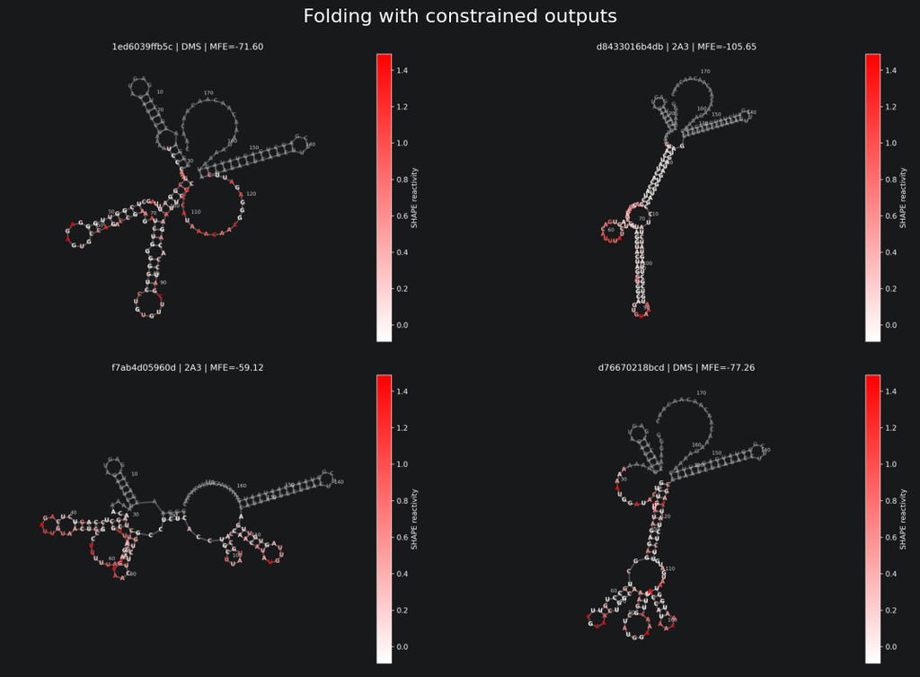

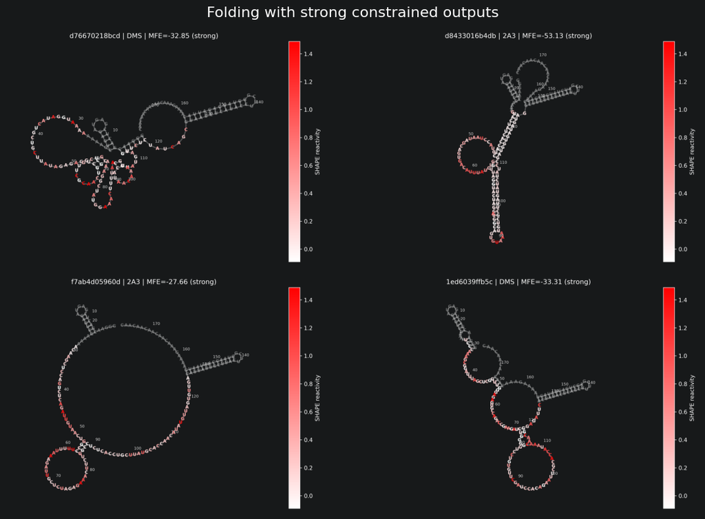

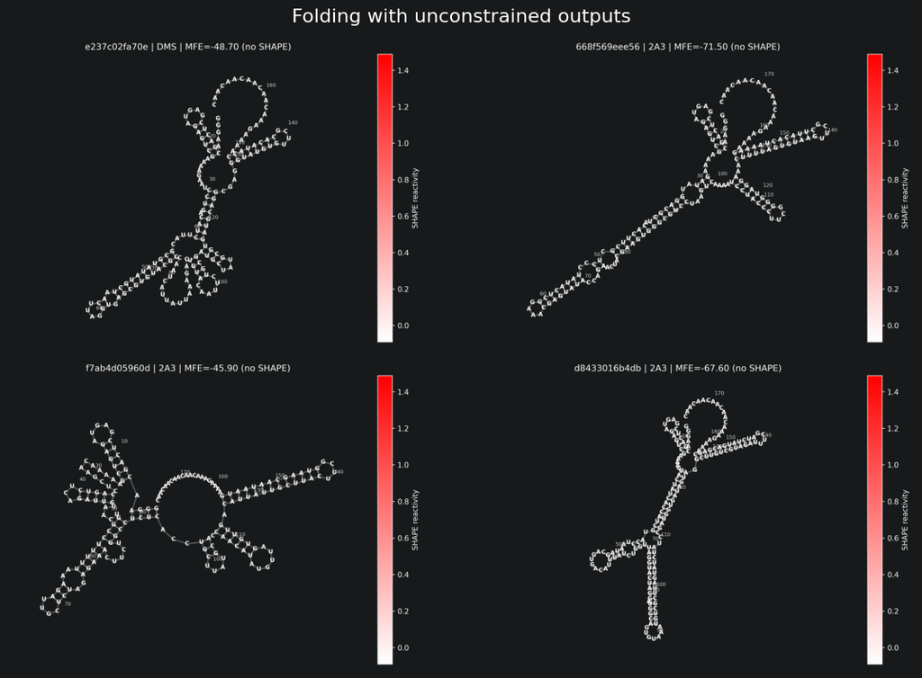

```python
def show_grid(pattern, title):
    files = glob.glob(pattern)[:6]

    fig, axes = plt.subplots(2, 2, figsize=(12, 8))
    fig.suptitle(title, color="white", fontsize=16)

    for ax, f in zip(axes.flatten(), files):
        ax.imshow(Image.open(f))
        #ax.set_title(f.split("/")[-1], color="white")
        ax.axis("off")
        ax.set_facecolor(dark_col)  # ensure no bright borders

    plt.tight_layout()
    plt.show()


show_grid("rna_kaggle_skeleton/outputs/constrained/*.png",       "Folding with constrained outputs")
show_grid("rna_kaggle_skeleton/outputs/strong_constrained/*.png","Folding with strong constrained outputs")
show_grid("rna_kaggle_skeleton/outputs/unconstrained/*.png",     "Folding with unconstrained outputs")
```